# Intro to ARMA models

## Topics

Autoregressive (AR) models

Moving average (MA) models

Autoregressive moving average (ARMA) models

Using ACF & PACF for model ID

## Autoregressive (AR) models

Autoregressive models are widely used in ecology to treat a current state of nature as a function its past state(s)

## Autoregressive (AR) models

An *autoregressive* model of order *p*, or AR(*p*), is defined as

\[ x_t = \phi_1 x_{t-1} + \phi_2 x_{t-2} + \dots + \phi_p x_{t-p} + w_t \]

where we assume

1. \(w_t\) is white noise
2. \(\phi_p \neq 0\) for an order-*p* process

## Examples of AR(*p*) models

AR(1)

\(x_t = 0.5 x_{t-1} + w_t\)

AR(1) with \(\phi_1 = 1\) (random walk)

\(x_t = x_{t-1} + w_t\)

AR(2)

\(x_t = -0.2 x_{t-1} + 0.4 x_{t-2} + w_t\)

## Examples of AR(*p*) models

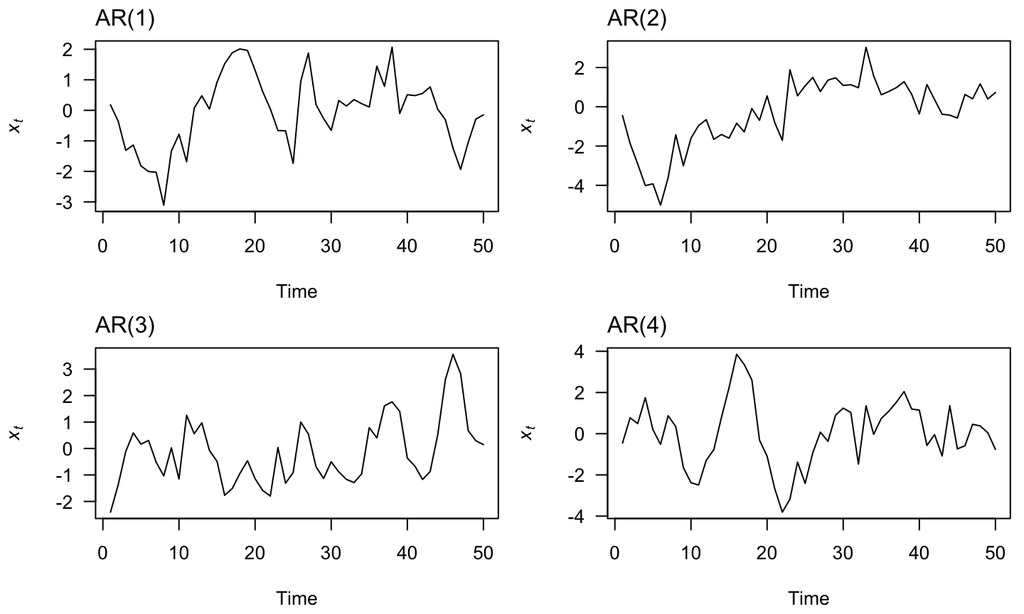

## Stationary AR(*p*) models

Recall that *stationary* processes have the following properties

1. no systematic change in the mean or variance
2. no systematic trend
3. no periodic variations or seasonality

## Stationary AR(1) models

AR(1) models are stationary if and only if \(\lvert \phi \rvert < 1\)

## Coefficients of AR(1) models

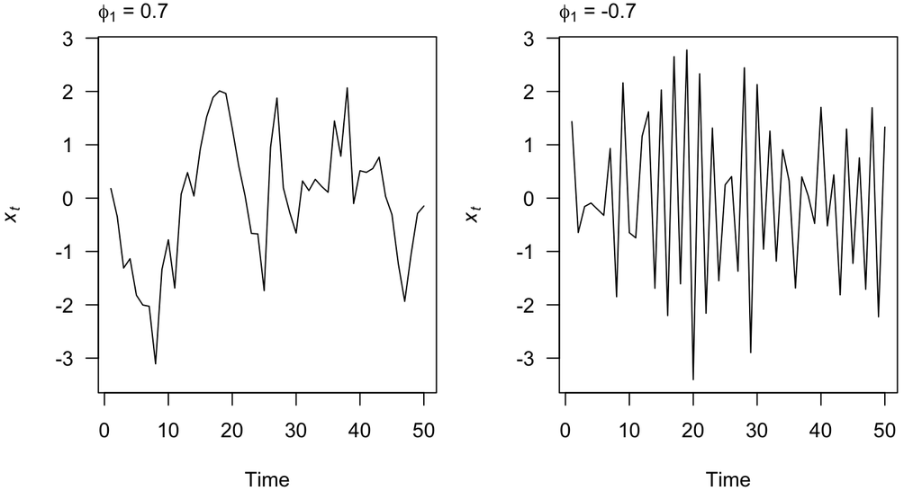

Same value, but different sign

## Coefficients of AR(1) models

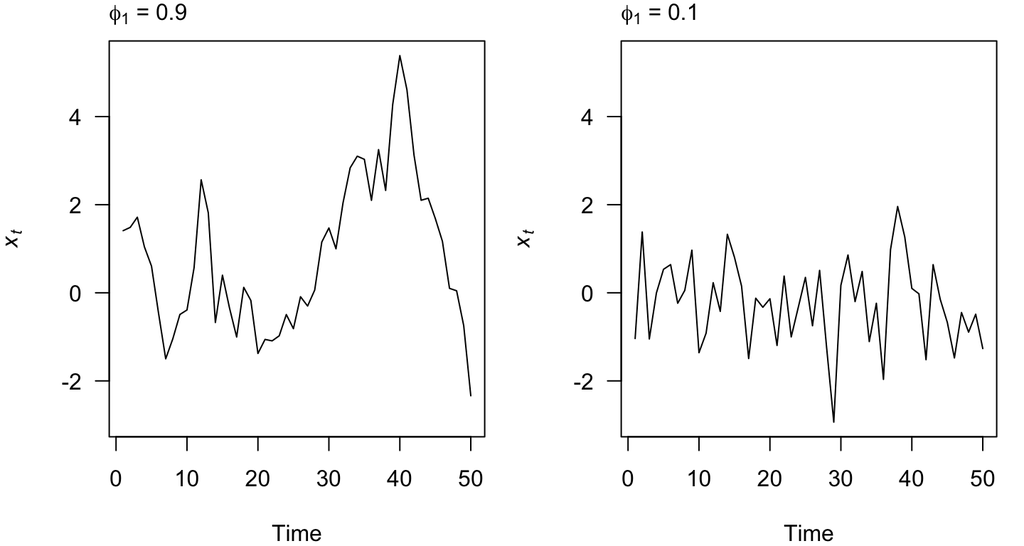

Both positive, but different magnitude

## Autocorrelation function (ACF)

Recall that the *autocorrelation function* (\(\rho_k\)) measures the correlation between \(\{x_t\}\) and a shifted version of itself \(\{x_{t+k}\}\)

## ACF for AR(1) models

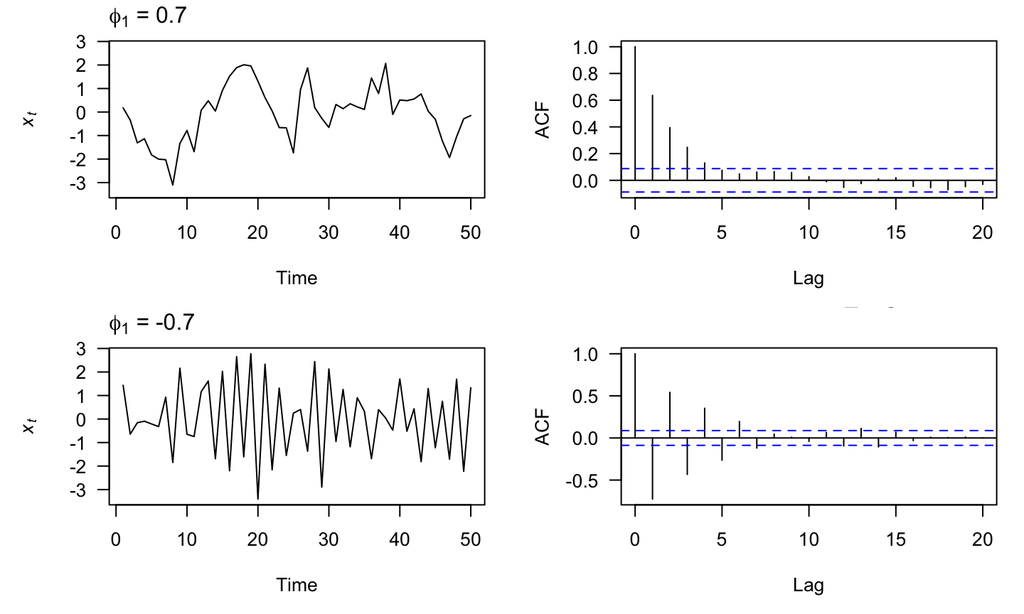

ACF oscillates for model with \(-\phi\)

## ACF for AR(1) models

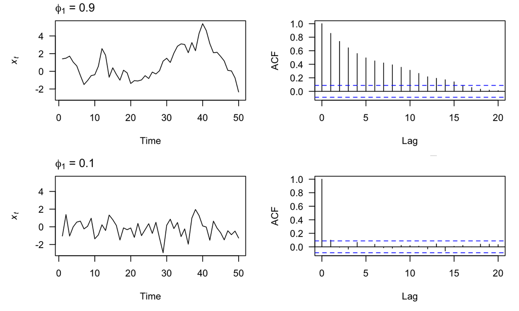

For model with large \(\phi\), ACF has longer tail

## Partial autocorrelation funcion (PACF)

Recall that the *partial autocorrelation function* (\(\phi_k\)) measures the correlation between \(\{x_t\}\) and a shifted version of itself \(\{x_{t+k}\}\), with the linear dependence of \(\{x_{t-1},x_{t-2},\dots,x_{t-k-1}\}\) removed

## ACF & PACF for AR(*p*) models

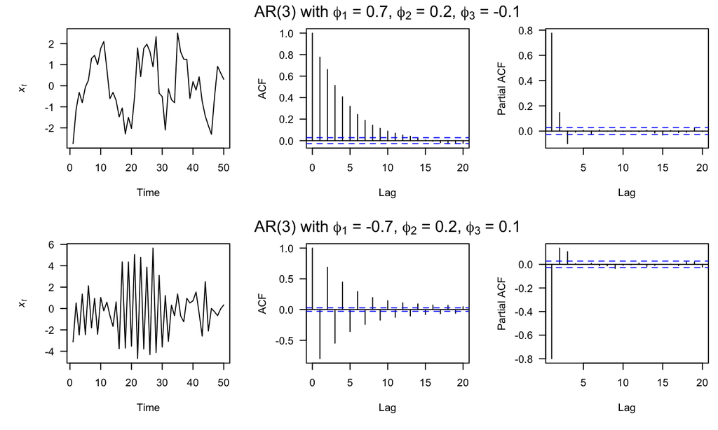

## PACF for AR(*p*) models

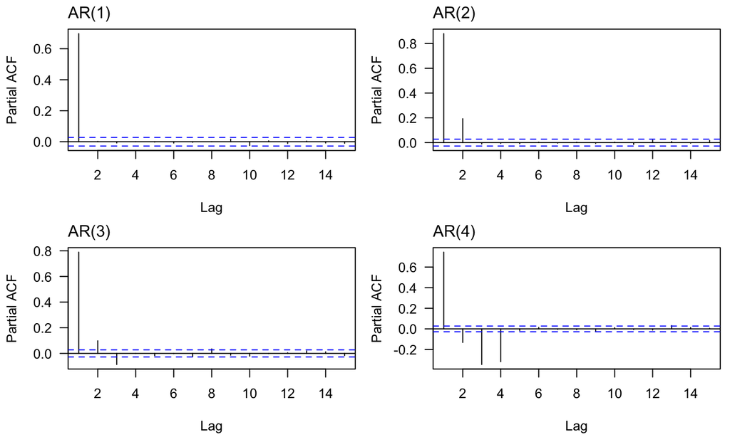

Do you see the link between the order *p* and lag *k*?

## Using ACF & PACF for model ID

| Model | ACF | PACF |
| --- | --- | --- |
| AR(*p*) | Tails off slowly | Cuts off after lag *p* |

## Moving average (MA) models

Moving average models are most commonly used for forecasting a future state

## Moving average (MA) models

A moving average model of order *q*, or MA(*q*), is defined as

\[ x_t = w_t + \theta_1 w_{t-1} + \theta_2 w_{t-2} + \dots + \theta_q w_{t-q} \]

where \(w_t\) is white noise

Each of the \(x_t\) is a sum of the most recent error terms

## Moving average (MA) models

A moving average model of order *q*, or MA(*q*), is defined as

\[ x_t = w_t + \theta_1 w_{t-1} + \theta_2 w_{t-2} + \dots + \theta_q w_{t-q} \]

where \(w_t\) is white noise

Each of the \(x_t\) is a sum of the most recent error terms

Thus, *all* MA processes are stationary because they are finite sums of stationary WN processes

## Examples of MA(*q*) models

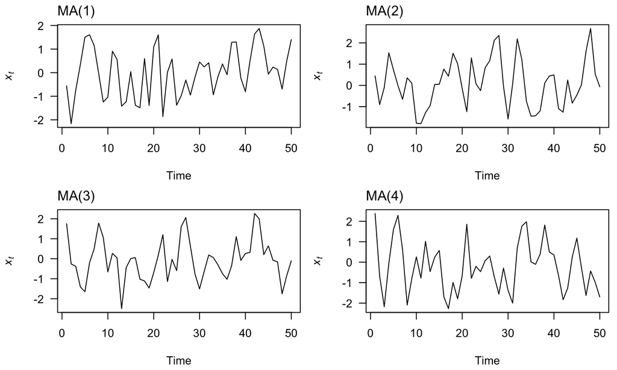

## Examples of MA(*q*) models

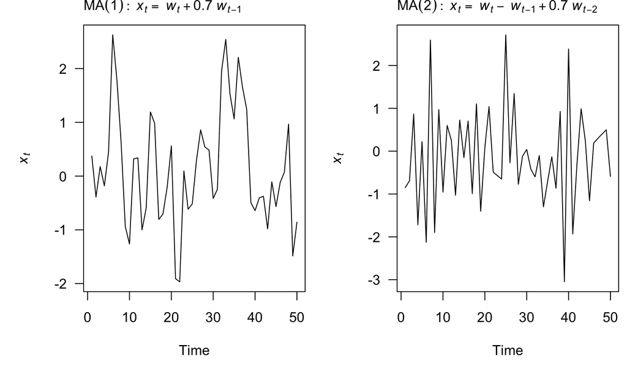

## ACF & PACF for MA(*q*) models

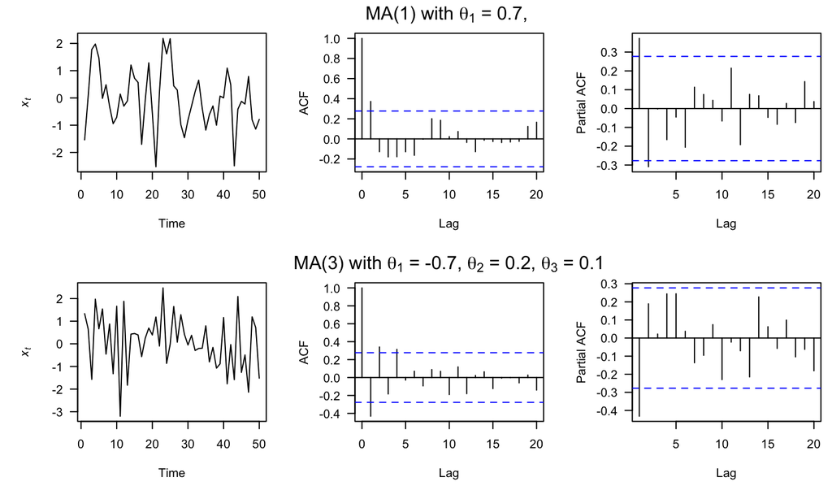

## ACF for MA(*q*) models

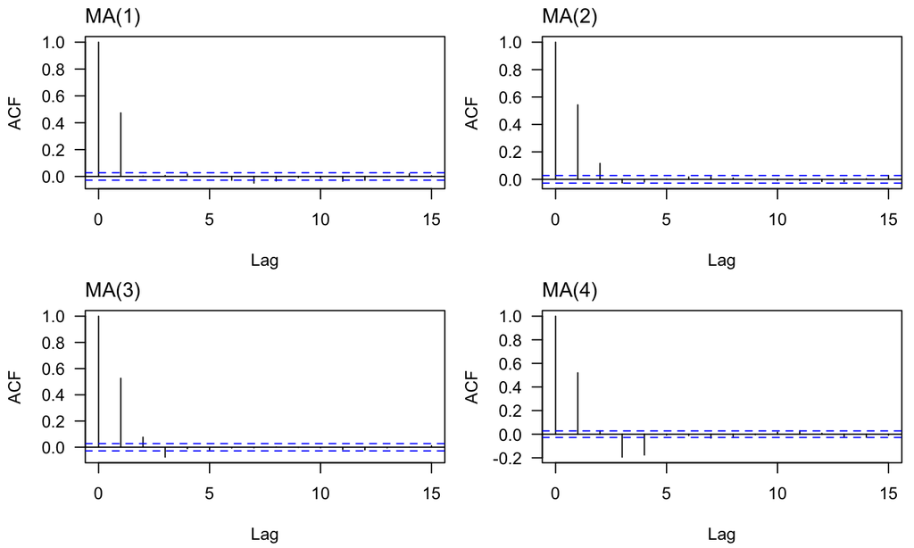

Do you see the link between the order *q* and lag *k*?

## Using ACF & PACF for model ID

| Model | ACF | PACF |
| --- | --- | --- |
| AR(*p*) | Tails off slowly | Cuts off after lag *p* |
| MA(*q*) | Cuts off after lag *q* | Tails off slowly |

## Using ACF & PACF for model ID

## Autoregressive moving average models

An autoregressive moving average, or ARMA(*p*,*q*), model is written as

\[ x_t = \phi_1 x_{t-1} + \dots + \phi_p x_{t-p} + w_t + \theta_1 w_{t-1} + \dots + \theta_q w_{t-q} \]

## Autoregressive moving average models

We can write an ARMA(*p*,*q*) model using the backshift operator

\[ \phi_p (\mathbf{B}) x_t= \theta_q (\mathbf{B}) w_t \]

ARMA models are *stationary* if all roots of \(\phi_p (\mathbf{B}) > 1\)

ARMA models are *invertible* if all roots of \(\theta_q (\mathbf{B}) > 1\)

## Examples of ARMA(*p*,*q*) models

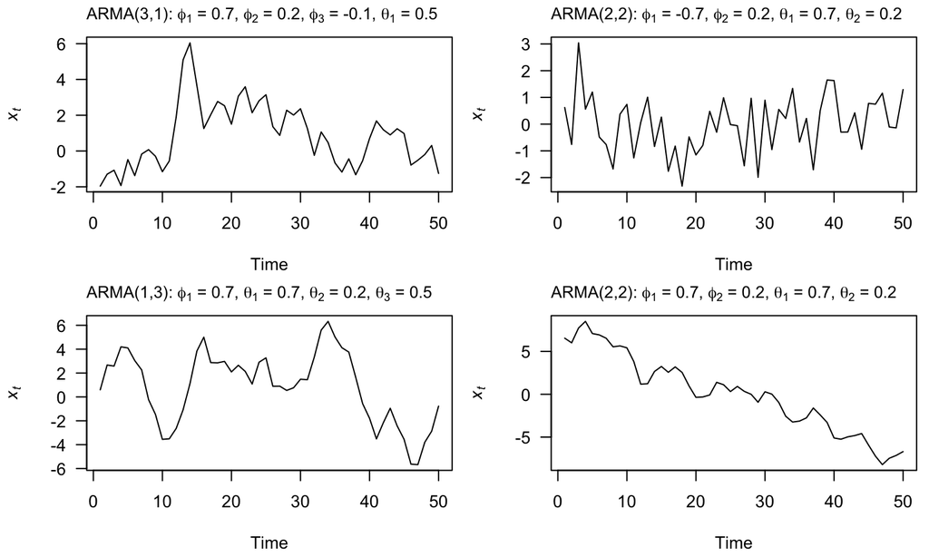

## ACF for ARMA(*p*,*q*) models

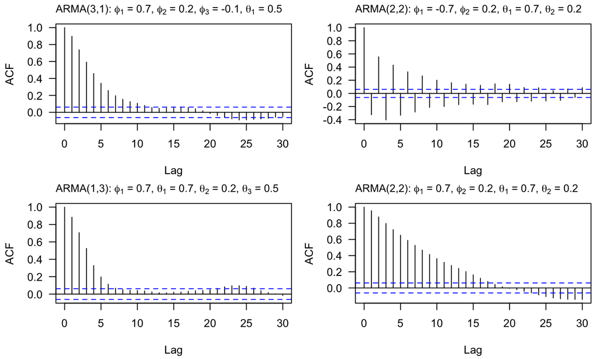

## PACF for ARMA(*p*,*q*) models

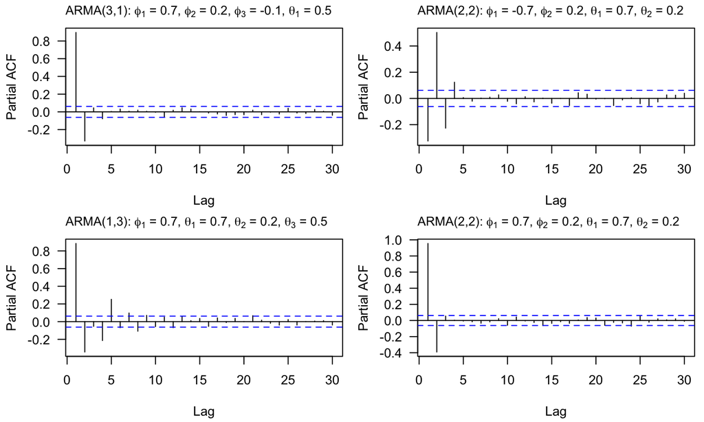

## Using ACF & PACF for model ID

| Model | ACF | PACF |
| --- | --- | --- |
| AR(*p*) | Tails off slowly | Cuts off after lag *p* |
| MA(*q*) | Cuts off after lag *q* | Tails off slowly |
| ARMA(*p*,*q*) | Tails off slowly | Tails off slowly |

NONSTATIONARY MODELS

## Autoregressive integrated moving average (ARIMA) models

If the data do not appear stationary, differencing can help

This leads to the class of *autoregressive integrated moving average* (ARIMA) models

ARIMA models are indexed with orders (*p*,*d*,*q*) where *d* indicates the order of differencing

## ARIMA(*p*,*d*,*q*) models

For \(d > 0\), \(\{x_t\}\) is an ARIMA(*p*,*d*,*q*) process if \((1-\mathbf{B})^d x_t\) is an ARMA(*p*,*q*) process

## ARIMA(*p*,*d*,*q*) models

For \(d > 0\), \(\{x_t\}\) is an ARIMA(*p*,*d*,*q*) process if \((1-\mathbf{B})^d x_t\) is an ARMA(*p*,*q*) process

For example, if \(\{x_t\}\) is an ARIMA(1,1,0) process then \(\nabla \{x_t\}\) is an ARMA(1,0) = AR(1) process

## ARIMA(*p*,*d*,*q*) models

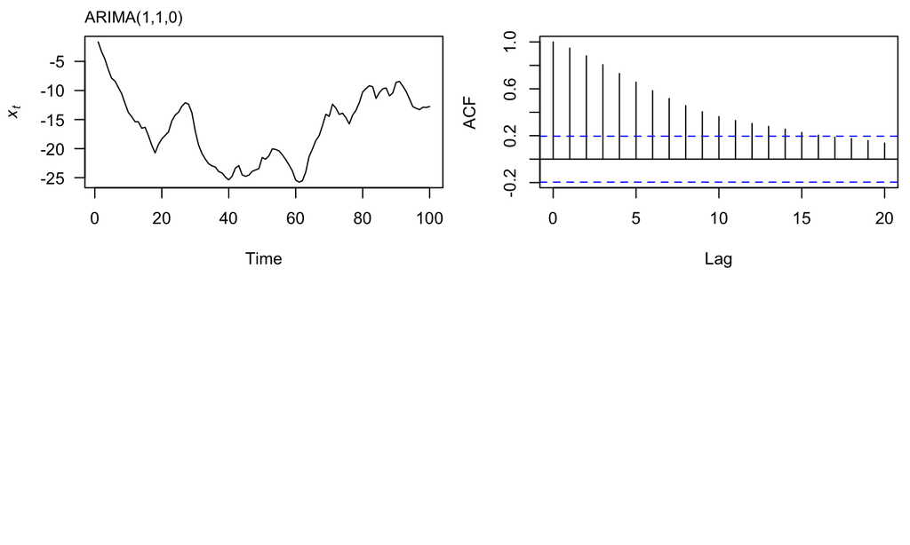

## ARIMA(*p*,*d*,*q*) models

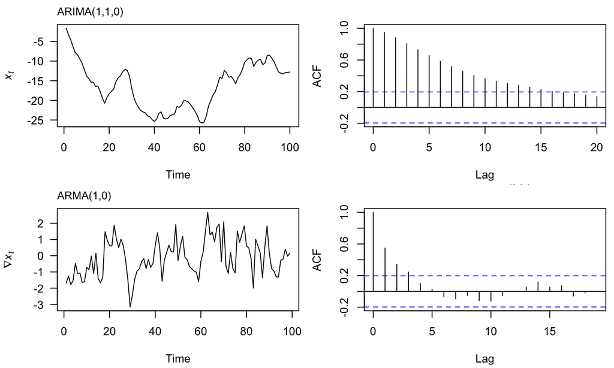